# SARS-CoV-2 Variants Co-infection

September 16, 2025

## **Lineage assignment**

### Pangolin and Nextclade

Lineage assigment table using Pangolin and Nextclade of all samples.

| Sample | Coverage | Pangolin | Scorpio | Nextclade | WHO clade | Note |
| --- | --- | --- | --- | --- | --- | --- |
| EPI_ISL_2661789 | 99.49% | B.1.1.28 | NA | B.1.1.28 | NA | Usher placements: B.1.1.28(1/1) |
| EPI_ISL_2491769 | 99.6% | B.1.1.28 | NA | N.9 | NA | Usher placements: B.1.1.28(1/2) N.9(1/2) |
| EPI_ISL_2677092 | 99.45% | B.1.1 | NA | P.1 | Gamma | Usher placements: B.1.1(1/2) B.1.1.28(1/2) |
| EPI_ISL_2645599 | 99.55% | B.1.1 | NA | P.1 | Gamma | Usher placements: B.1.1(1/2) B.1.1.28(1/2) |
| EPI_ISL_1068258 | 99.43% | P.1 | NA | P.1 | Gamma | Usher placements: P.1(1/1) |
| EPI_ISL_2491781 | 99.44% | B.1.1 | NA | P.1 | Gamma | Usher placements: B.1.1(1/2) B.1.1.28(1/2) |
| EPI_ISL_2661931 | 99.59% | B.1.1 | NA | P.1 | Gamma | Usher placements: B.1.1(1/2) B.1.1.28(1/2) |
| EPI_ISL_3869215 | 99.78% | B.1.1 | NA | P.2 | NA | Usher placements: B.1.1(1/2) B.1.1.28(1/2) |
| EPI_ISL_2777552 | 99.51% | P.1 | NA | P.1 | Gamma | Usher placements: P.1(1/1) |

### Freyja

The Freyja plot shows the relative SARS-CoV-2 lineage abundance in each sample. Samples suspect for coinfection will illustrate mixed prevalence of two or more variants. The plots below shows the summarized and specific lineages and their corresponding abundance as detected by Freyja.

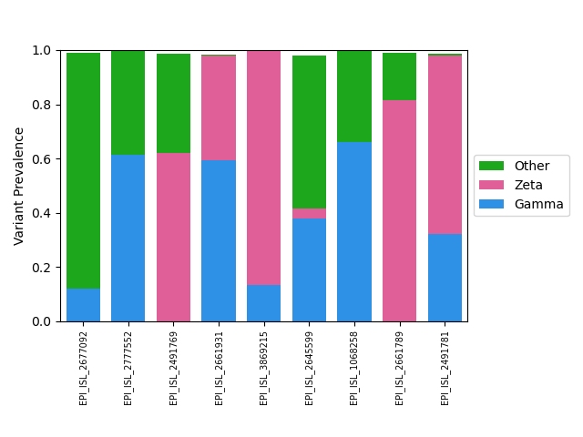

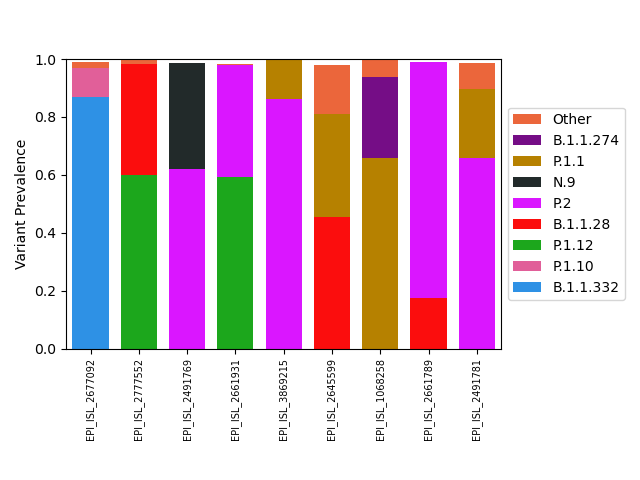

### VirStrain

Samples were analyzed using the VirStrain tool against a database of representative SARS-CoV-2 sequences. The results are summarized in the table below, where the ‘Most Possible Strain’ represents the lineage with the highest Vscore in the initial iteration. Meanwhile, the ‘Other Possible Strain’ is identified by the highest Vscore in subsequent iterations.

| Sample | Most Possible Strain | Other Possible Strain | Valid Map Rate |
| --- | --- | --- | --- |
| EPI_ISL_2777552 | Gamma_P.1 | AZ.5 | 2/93 |
| EPI_ISL_3869215 | Zeta_P.2 | Gamma | 2/93 |
| EPI_ISL_1068258 | Gamma_P.1 | AY.43 | 2/93 |
| EPI_ISL_2491781 | Zeta_P.2 | Gamma | 3/93 |
| EPI_ISL_2677092 | NA | Gamma | 3/93 |
| EPI_ISL_2645599 | Gamma_P.1 | Zeta | 3/93 |
| EPI_ISL_2661931 | Gamma_P.1 | Zeta | 3/93 |
| EPI_ISL_2661789 | Zeta_P.2 | Iota | 1/93 |
| EPI_ISL_2491769 | Zeta_P.2 | Delta | 2/93 |

## **Nucleotide mixture per position**

The figure below shows the bammix plot for nucleotide mixtures of the sample/s with potential SARS-CoV-2 variants coinfection. Multiple sites containing heterogenous bases crossing the set threshold (default >20% minor alelle) mixture will be apparent.

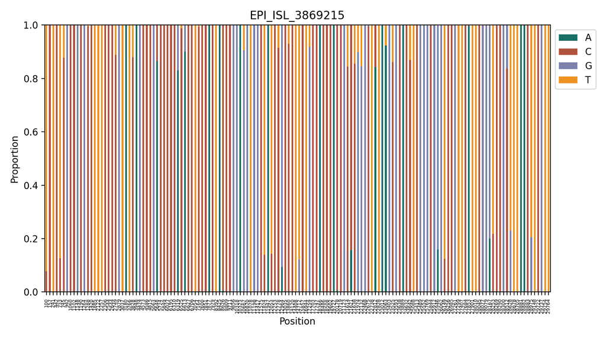

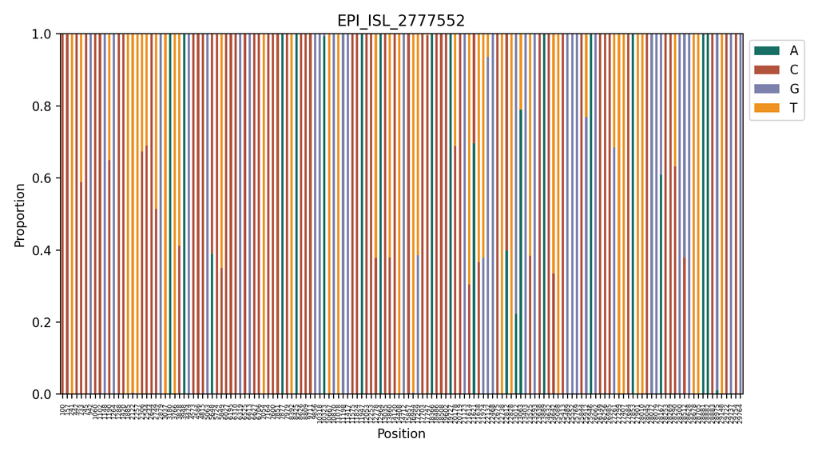

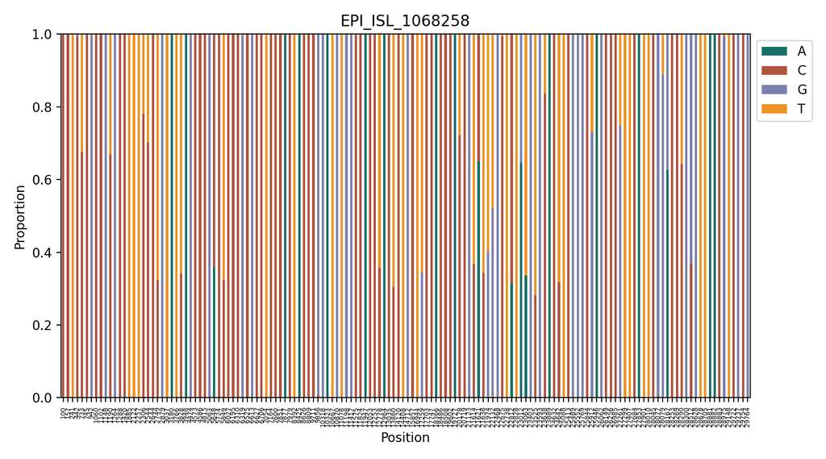

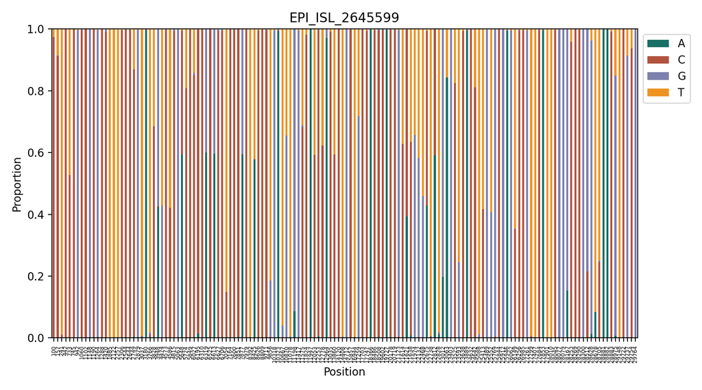

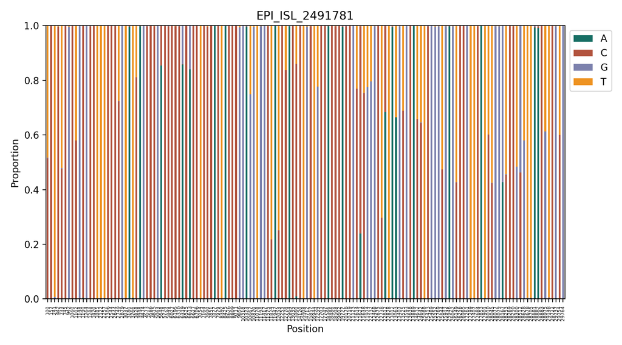

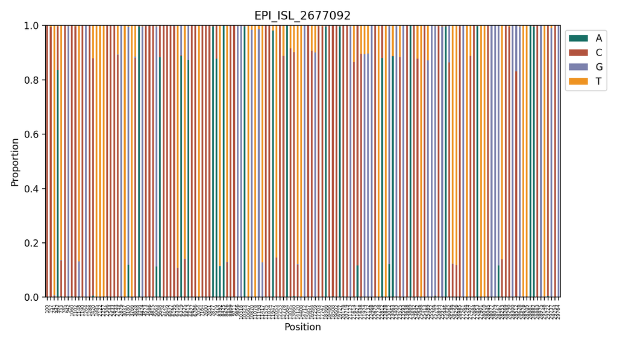

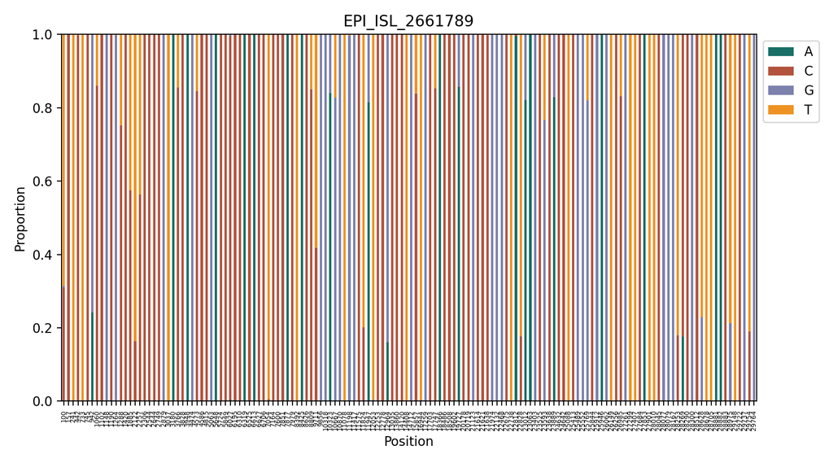

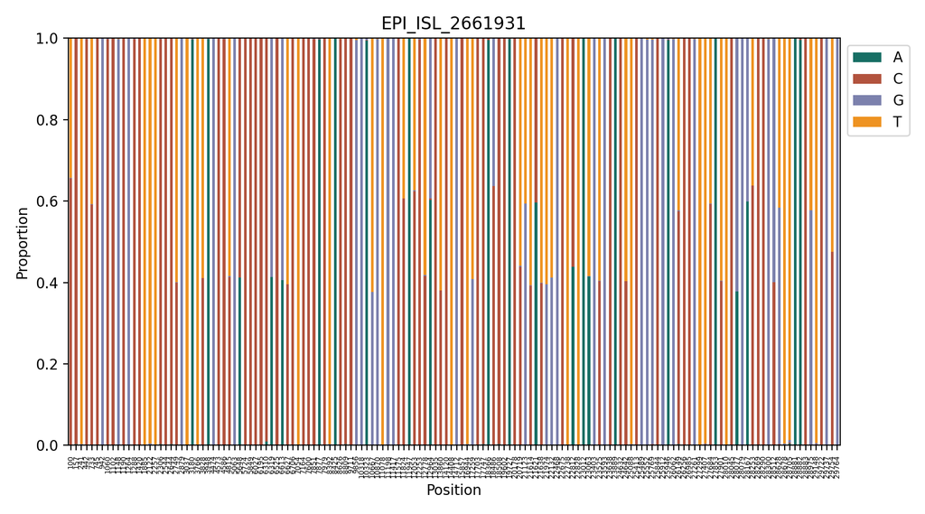

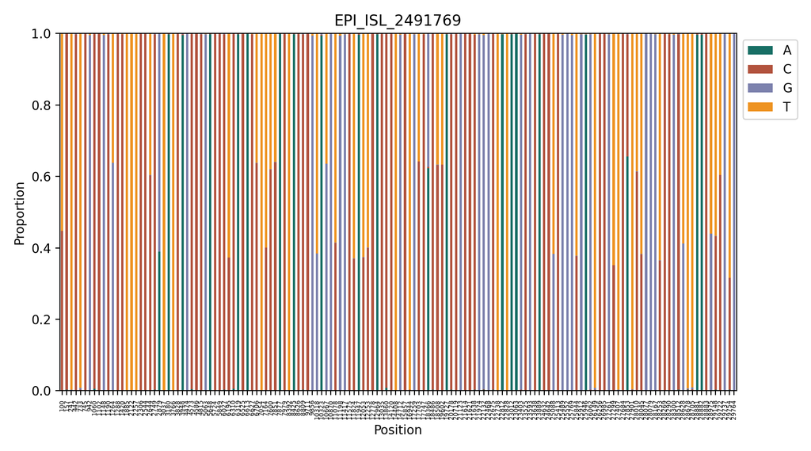

## **Alternative allele fraction**

### For each lineage-defining mutations

The alternative allele fraction (AAF) determines the number of reads supporting each variant detected in the sample/s. The AAF per mutation of sample/s flagged for SARS-CoV-2 coinfection are shown in the figure.

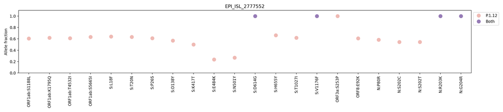

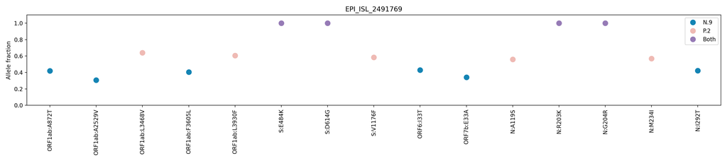

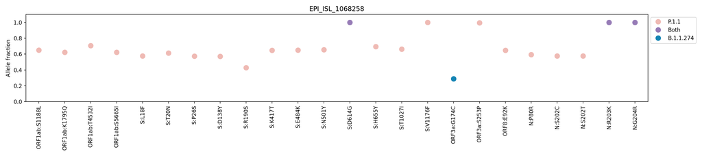

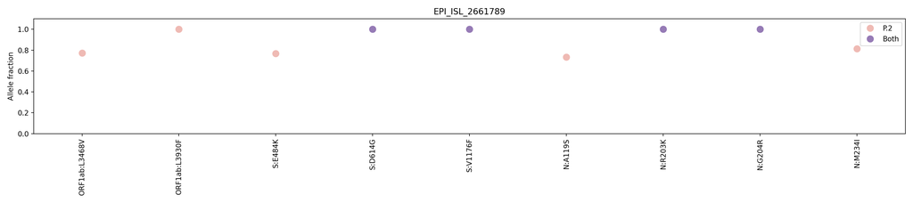

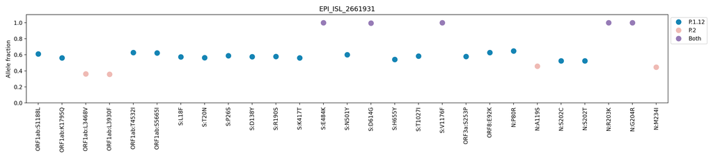

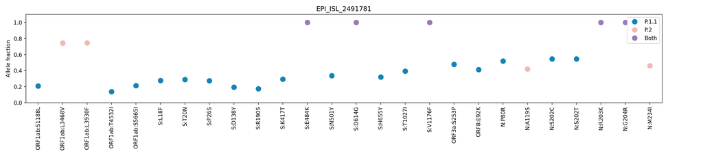

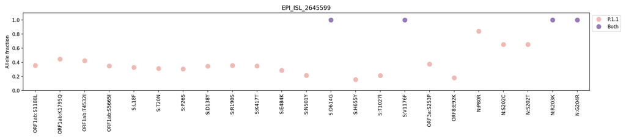

### For each amplicon

The AAF for each amplicon is plotted by getting the average allele fraction for each lineage within the range of that amplicon.

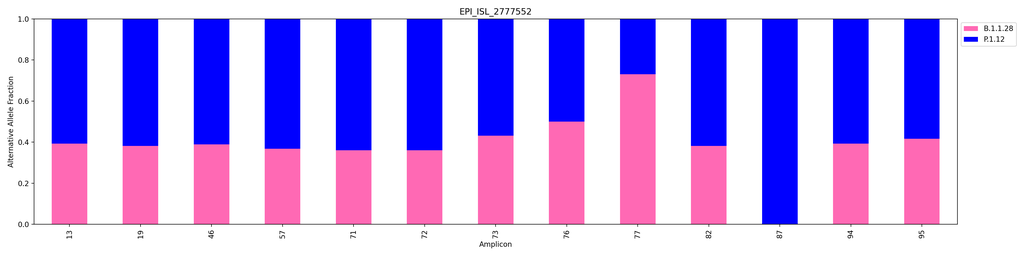

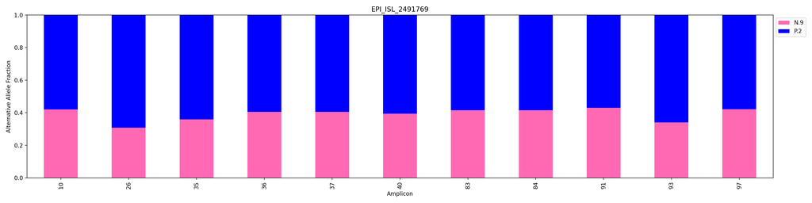

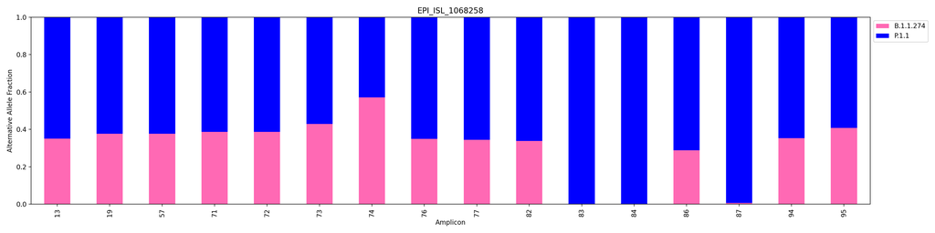

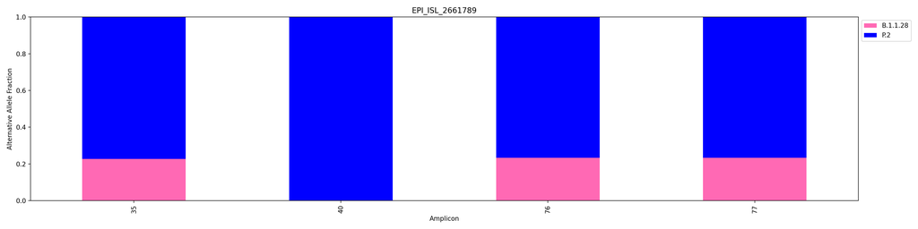

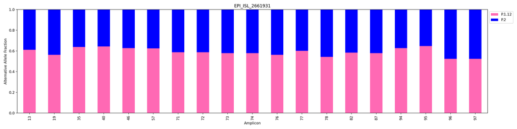

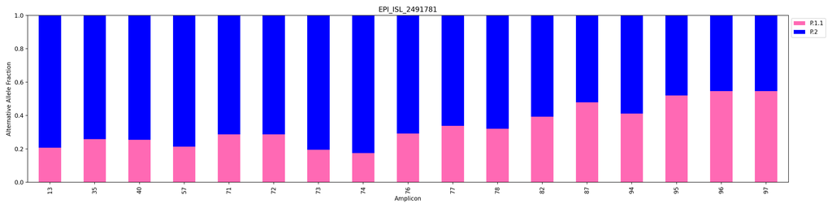

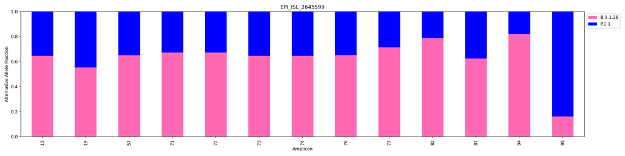

## **Amplicon sorting**

| Sample | Coverage | Pangolin | Scorpio | Nextclade | WHO clade | Note |
| --- | --- | --- | --- | --- | --- | --- |
| EPI_ISL_2491781_lineage_A | 99.98% | P.1 | Gamma (P.1-like) | P.1 | Gamma | Usher placements: P.1(1/1) |
| EPI_ISL_2491781_lineage_B | 99.98% | P.2 | NA | P.2 | NA | Usher placements: P.2(1/1) |
| EPI_ISL_2645599_lineage_A | 99.98% | B.1.1.33 | NA | B.1.1 | NA | Usher placements: B.1.1.33(1/1) |
| EPI_ISL_2645599_lineage_B | 99.98% | P.2 | NA | P.2 | NA | Usher placements: P.2(1/1) |
| EPI_ISL_1068258_lineage_A | 99.99% | B.1.1.274 | NA | B.1.1.274 | NA | Usher placements: B.1.1.274(1/1) |
| EPI_ISL_1068258_lineage_B | 99.99% | P.1 | Gamma (P.1-like) | P.1 | Gamma | Usher placements: P.1(1/1) |
| EPI_ISL_2491769_lineage_A | 99.98% | B.1.1.28 | NA | B.1.1.28 | NA | Usher placements: B.1.1.28(1/1) |
| EPI_ISL_2491769_lineage_B | 99.98% | P.2 | NA | P.2 | NA | Usher placements: P.2(1/1) |
| EPI_ISL_2661931_lineage_A | 99.98% | B.1.1.28 | NA | B.1.1.28 | NA | Usher placements: B.1.1.28(1/1) |
| EPI_ISL_2661931_lineage_B | 99.97% | P.1 | Gamma (P.1-like) | P.1 | Gamma | Usher placements: P.1(1/1) |
| EPI_ISL_2777552_lineage_A | 99.99% | B.1.1.28 | NA | B.1.1.28 | NA | Usher placements: B.1.1.28(1/1) |
| EPI_ISL_2777552_lineage_B | 99.99% | P.1 | Gamma (P.1-like) | P.1 | Gamma | Usher placements: P.1(1/1) |
| EPI_ISL_2661789_lineage_A | 99.99% | B.1.1 | NA | B.1.1.28 | NA | Usher placements: B.1.1(1/2) B.1.1.28(1/2) |
| EPI_ISL_2661789_lineage_B | 100.0% | P.2 | NA | P.2 | NA | Usher placements: P.2(1/1) |

## **References**

The tools used in this [pipeline](https://github.com/lanadelrea/CoPi) are as follows:

- [Pangolin](https://github.com/cov-lineages/pangolin)
- [Nextclade](https://github.com/nextstrain/nextclade)
- Freyja
- VirStrain
- [Bammix](https://github.com/chrisruis/bammix)
- Custom scripts adapted from [Bolze et al.](https://doi.org/10.1016/j.medj.2022.10.002)